# OCAP Activity Models - Longitudinal Models of the MIECHV Effectiveness and Statewide Trends

OUHSC MIECHV External Evaluation Team

[output not shown]

[output not shown]

[output not shown]

This report covers the longitudinal models of the MIECHV effectiveness and of statewide trends. It is relevant to Aim 1C (“Evaluate the frequency of referrals coming into EBHV agencies”), Aim 3A (“Continually evaluate the flow of clients served per county”), Aim 3D (“Evaluate effectiveness of new engagement enhancement strategies”), and Aim 5C (“Implement and evaluate system of quality improvements and controls”) of [HRSA/ACF D89MC23154](http://ouhscbbmc.github.io/MReportingPublic/research-2011a.html) Investigation.

The underlying dataset contains information from 37 programs, 17,235 completed referrals, 6,542 completed enrollments, and 131,442 completed visits. It summarizes OCAP activity between 2009-01-15 and 2015-12-15. The date used for the introduction of MIECHV funds is 2012-06-15.

To be included in the analysis, a program must have at least 30 visits and 12 consecutive months of clients.

The processes for gathering and reshaping the data was described in [C1 Activity Methods](http://ouhscbbmc.github.io/MReportingPublic/reports/2011/c1-activity-methods-description.pdf). Information about county and region demographics is available in [OSDH Maps](http://ouhscbbmc.github.io/MReportingPublic/reports/osdh-maps.html).

# 1 Milestones

One of this investigation’s goals is to assess if performance changes following significant events in Oklahoma’s home visiting programs. The following dates are of particular interest. A more detailed is found on our project’s [interactive timeline](http://ouhscbbmc.github.io/MReportingPublic/reports/Aim1B.html).

|  | Start Date | Stop Date | Description |
| --- | --- | --- | --- |
| Cohort 0 | Jan 01, 2009 | Jun 14, 2012 | Comparison period before any MIECHV activities. |
| Community Connector | May 01, 2012 | Present | Community Connector,Community Connector contracts start. (Six counties in Summer & Fall 2012. Comanche stops July 2013. Garfield stops Sept 2014. Kay & Muskogee stops Sept 2015.) |
| Cohort 1 or 2 | Jun 15, 2012 | Present | Program funds are spent in the counties. |
| Cohort 1 | Jun 15, 2012 | Dec 31, 2014 | Program funds start being spent in the counties. |
| Cohort 2 | Jan 01, 2015 | Present | Program funds continue being spent in the counties. |
| Ad Waves | Apr 01, 2014 | Jun 30, 2015 | parentPRO ad campaigns in 2014 and 2015 |
| Ad Waves Lagged | Jun 01, 2014 | Jun 30, 2015 | parentPRO ad campaigns in 2014 and 2015 |
| Ad Wave 1 | Apr 01, 2014 | Jun 30, 2014 | parentPRO ad campaign concentrated in May. |
| Ad Wave 1 Lagged | Jun 01, 2014 | Jun 30, 2014 | parentPRO ad campaign concentrated in May. |
| Ad Wave 2 | Sep 01, 2014 | Oct 30, 2014 | parentPRO ad campaign concentrated in late Sept. |
| Ad Wave 2 Lagged | Oct 01, 2014 | Oct 30, 2014 | parentPRO ad campaign concentrated in late Sept. |
| Referral Restrictions Lifted | May 23, 2014 | Present | Substantial restrictions lifted for inter-agency collaboration. |
| ETO Transition | Jan 01, 2015 | Apr 30, 2015 | Staff transitions from OCAPPA data system to ETO (deployed Jan 1). |
| parentPRO Website | Apr 02, 2015 | Present | The state’s umbrella website is deployed. |
| Ad Wave 3 | May 01, 2015 | Jun 30, 2015 | parentPRO ad campaign concentrated in late May. |
| Ad Wave 3 Lagged | Jun 01, 2015 | Jun 30, 2015 | parentPRO ad campaign concentrated in late May. |

```
The next table shows how many months (with outcomes) belong to a `MiechvEver` program, separated by model.  Very few (if any) comparison points are available for PAT or SC.
```

|  | HFA | PAT | SC |
| --- | --- | --- | --- |
| FALSE | 1154 | 47 | 0 |
| TRUE | 336 | 156 | 95 |

| Model | Sites | Referrals | Enrollments | Visits Completed | Visits Failed |
| --- | --- | --- | --- | --- | --- |
| HFA | 23 | 13,528 | 3,494 | 93,939 | 26,387 |
| PAT | 10 | 1,793 | 1,061 | 17,483 | 4,962 |
| SC | 4 | 761 | 1,553 | 6,255 | 1,990 |

| Model | Year | Sites | Referrals | Enrollments | Visits Completed | Visits Failed |
| --- | --- | --- | --- | --- | --- | --- |
| HFA | 2009 | 22 | 3,077 | 703 | 17,076 | 4,756 |
| HFA | 2010 | 22 | 2,897 | 678 | 17,597 | 5,003 |
| HFA | 2011 | 22 | 2,389 | 559 | 15,305 | 4,867 |
| HFA | 2012 | 22 | 1,681 | 413 | 12,016 | 3,178 |
| HFA | 2013 | 15 | 1,413 | 426 | 10,552 | 2,588 |
| HFA | 2014 | 15 | 1,427 | 412 | 12,144 | 3,046 |
| HFA | 2015 | 13 | 644 | 303 | 9,249 | 2,949 |
| PAT | 2009 | 1 | 0 | 0 | 393 | 42 |
| PAT | 2010 | 1 | 0 | 0 | 332 | 32 |
| PAT | 2013 | 5 | 224 | 186 | 775 | 181 |
| PAT | 2014 | 6 | 581 | 507 | 7,865 | 2,088 |
| PAT | 2015 | 9 | 988 | 368 | 8,118 | 2,619 |
| SC | 2011 | 1 | 87 | 117 | 302 | 102 |
| SC | 2012 | 1 | 113 | 281 | 794 | 184 |
| SC | 2013 | 1 | 110 | 297 | 911 | 245 |
| SC | 2014 | 3 | 148 | 383 | 1,410 | 381 |
| SC | 2015 | 4 | 303 | 475 | 2,838 | 1,078 |

# 2 Modeling and Graphical Analysis

```
               coefficient letter   beta change     p
1               MiechvEver      a -1.023   0.36  .022
2                  Cohort1      b -0.397   0.67  .001
3                  Cohort2      c -1.391   0.25 <.001
4 Cohort1:MiechvContracted      d  0.388   1.47 <.001
5 Cohort2:MiechvContracted      e  0.865   2.37 <.001
```

```
               coefficient letter   beta change     p
1               MiechvEver      a -0.918   0.40  .036
2                  Cohort1      b -0.155   0.86  .149
3                  Cohort2      c -0.788   0.45 <.001
4 Cohort1:MiechvContracted      d  0.320   1.38  .003
5 Cohort2:MiechvContracted      e  0.804   2.23  .003
```

```
               coefficient letter   beta change     p
1               MiechvEver      a -1.460   0.23  .001
2                  Cohort1      b -0.017   0.98  .585
3                  Cohort2      c -0.132   0.88  .002
4 Cohort1:MiechvContracted      d  0.078   1.08  .001
5 Cohort2:MiechvContracted      e  0.175   1.19  .002
```

```
[1] FALSE
```

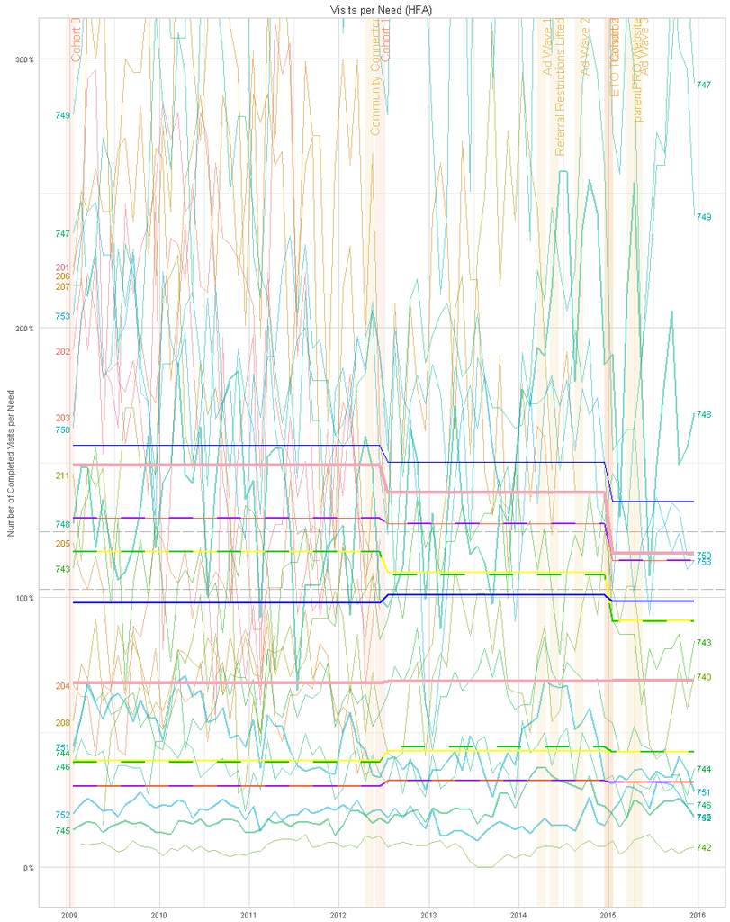

```
  visit_miechv_ever visit_intercept_mean visit_cohort_1_mean visit_cohort_2_mean
1             FALSE           0.04411677        -0.002463309        -0.007003136
2              TRUE          -0.20955466         0.011700718         0.033264897
```

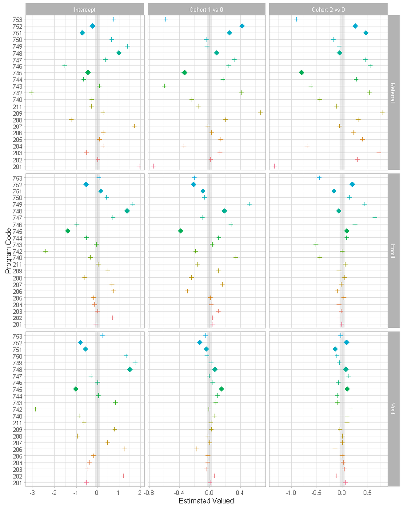

```
  miechv_ever referral_intercept_mean referral_cohort_1_mean referral_cohort_2_mean
1       FALSE              0.01745512            -0.02329443            0.006443574
2        TRUE             -0.08291182             0.11064854           -0.030606976
  enroll_intercept_mean enroll_cohort_1_mean enroll_cohort_2_mean visit_intercept_mean
1            0.01850112           0.02608902          -0.00341452           0.04411677
2           -0.08788033          -0.12392285           0.01621897          -0.20955466
  visit_cohort_1_mean visit_cohort_2_mean
1        -0.002463309        -0.007003136
2         0.011700718         0.033264897
```

```
Generalized linear mixed model fit by maximum likelihood (Adaptive Gauss-Hermite Quadrature, nAGQ
  = 0) [glmerMod]
 Family: poisson  ( log )
Formula: EnrollCount ~ 1 + MiechvEver + Cohort1 + Cohort2 + MiechvContracted:Cohort1 +
    MiechvContracted:Cohort2 + (1 + Cohort1 + Cohort2 | RegionID) +
    (1 | QuarterF) + offset(log(ReferralCompleteCountMean3Months))
   Data: ds_program_month
      AIC       BIC    logLik  deviance  df.resid
 9855.165  9925.970 -4914.582  9829.165      1701
Random effects:
 Groups   Name        Std.Dev. Corr
 QuarterF (Intercept) 0.1668
 RegionID (Intercept) 0.2958
          Cohort1TRUE 0.4134   -0.30
          Cohort2TRUE 0.6629    0.40 -0.69
Number of obs: 1714, groups:  QuarterF, 28; RegionID, 9
Fixed Effects:
                      (Intercept)                     MiechvEverTRUE
                         -1.55793                            0.59920
                      Cohort1TRUE                        Cohort2TRUE
                          0.59461                            0.60565
Cohort1FALSE:MiechvContractedTRUE   Cohort1TRUE:MiechvContractedTRUE
                         -0.04079                           -0.29306
fit warnings:
fixed-effect model matrix is rank deficient so dropping 1 column / coefficient
```

```
   Min. 1st Qu.  Median    Mean 3rd Qu.    Max.    NA's
  1.000   4.000   7.000   8.988  12.000  57.000      74
```

# 3 Referrals

## 3.1 HFA – Referral

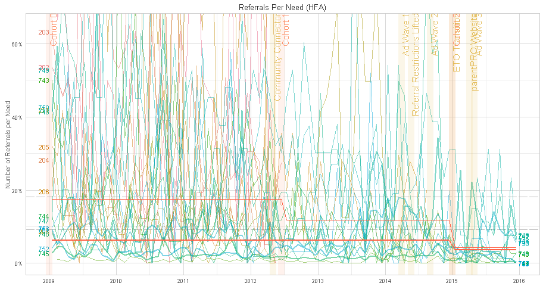

*Response variable*: `ReferralCompleteCount`

### 3.1.1 Two-rate coding –MIECHV Contracted

```
               coefficient letter   beta change     p
1               MiechvEver      a -1.023   0.36  .022
2                  Cohort1      b -0.397   0.67  .001
3                  Cohort2      c -1.391   0.25 <.001
4 Cohort1:MiechvContracted      d  0.388   1.47 <.001
5 Cohort2:MiechvContracted      e  0.865   2.37 <.001
Generalized linear mixed model fit by maximum likelihood (Adaptive Gauss-Hermite Quadrature, nAGQ
  = 0) [glmerMod]
 Family: poisson  ( log )
Formula: ReferralCompleteCount ~ 1 + MiechvEver + Cohort1 + Cohort2 +
    MiechvContracted:Cohort1 + MiechvContracted:Cohort2 + Lag1 +
    Lag2 + Lag3 + (1 + Cohort1 + Cohort2 + Lag1 + Lag2 + Lag3 |
    ProgramCode) + (1 | QuarterF) + offset(log(InfantNeedCountPerMonth))
   Data: d

     AIC      BIC   logLik deviance df.resid
  9365.7   9528.7  -4651.8   9303.7     1390

Random effects:
 Groups      Name        Variance Std.Dev. Corr
 QuarterF    (Intercept) 0.017292 0.13150
 ProgramCode (Intercept) 1.184912 1.08854
             Cohort1     0.161632 0.40204  -0.43
             Cohort2     0.399931 0.63240  -0.49  0.93
             Lag1        0.017510 0.13232  -0.65  0.62  0.56
             Lag2        0.008973 0.09472  -0.24 -0.04  0.29  0.11
             Lag3        0.013589 0.11657  -0.28  0.34  0.66  0.01  0.77
Number of obs: 1421, groups:  QuarterF, 27; ProgramCode, 23

Fixed effects:
                         Estimate Std. Error z value Pr(>|z|)
(Intercept)              -2.00908    0.24954  -8.051 8.21e-16
MiechvEver               -1.02347    0.44695  -2.290 0.022026
Cohort1                  -0.39736    0.11661  -3.408 0.000655
Cohort2                  -1.39141    0.18873  -7.373 1.67e-13
Lag1                      0.06084    0.03194   1.905 0.056786
Lag2                      0.04389    0.02535   1.731 0.083428
Lag3                      0.01503    0.02910   0.517 0.605479
Cohort1:MiechvContracted  0.38776    0.06975   5.559 2.71e-08
Cohort2:MiechvContracted  0.86479    0.12926   6.690 2.23e-11
```

### 3.1.2 Two-rate coding –Has Community Connector

```
           coefficient letter   beta change     p
1           MiechvEver      a -1.144   0.32  .008
2              Cohort1      b -0.338   0.71  .008
3              Cohort2      c -1.302   0.27 <.001
4 Cohort1:HasConnector      d -0.004   1.00  .965
5 Cohort2:HasConnector      e  0.540   1.72  .001
      AIC       BIC    logLik  deviance  df.resid
 9398.113  9561.145 -4668.056  9336.113  1390.000
```

### 3.1.3 Event: Ad Waves

*Event Description*: parentPRO ad campaigns in 2014 and 2015 - Apr 01, 2014

```
               coefficient letter   beta change     p
1                AdWaveAny      h  0.372   1.45 <.001
2               MiechvEver      i -1.025   0.36  .023
3                  Cohort1      j -0.461   0.63 <.001
4                  Cohort2      k -1.395   0.25 <.001
5 Cohort1:MiechvContracted      l  0.369   1.45 <.001
6 Cohort2:MiechvContracted      m  0.872   2.39 <.001
      AIC       BIC    logLik  deviance  df.resid
 9345.149  9513.441 -4640.575  9281.149  1389.000
```

### 3.1.4 Event: Ad Wave 1

*Event Description*: parentPRO ad campaign concentrated in May. - Apr 01, 2014

```
               coefficient letter   beta change     p
1                  AdWave1      h -0.039   0.96  .795
2               MiechvEver      i -1.025   0.36  .022
3                  Cohort1      j -0.394   0.67  .001
4                  Cohort2      k -1.392   0.25 <.001
5 Cohort1:MiechvContracted      l  0.389   1.48 <.001
6 Cohort2:MiechvContracted      m  0.866   2.38 <.001
      AIC       BIC    logLik  deviance  df.resid
 9367.584  9535.876 -4651.792  9303.584  1389.000
```

### 3.1.5 Event: Ad Wave 2

*Event Description*: parentPRO ad campaign concentrated in late Sept. - Sep 01, 2014

```
               coefficient letter   beta change     p
1                  AdWave2      h  0.435   1.54 <.001
2               MiechvEver      i -1.036   0.35  .021
3                  Cohort1      j -0.431   0.65 <.001
4                  Cohort2      k -1.398   0.25 <.001
5 Cohort1:MiechvContracted      l  0.371   1.45 <.001
6 Cohort2:MiechvContracted      m  0.876   2.40 <.001
      AIC       BIC    logLik  deviance  df.resid
 9339.542  9507.834 -4637.771  9275.542  1389.000
```

### 3.1.6 Event: Referral Restrictions Lifted

*Event Description*: Substantial restrictions lifted for inter-agency collaboration. - May 23, 2014

```
               coefficient letter   beta change     p
1                EraLifted      h -0.073   0.93  .346
2               MiechvEver      i -1.032   0.36  .021
3                  Cohort1      j -0.395   0.67  .001
4                  Cohort2      k -1.387   0.25 <.001
5 Cohort1:MiechvContracted      l  0.412   1.51 <.001
6 Cohort2:MiechvContracted      m  0.930   2.54 <.001
      AIC       BIC    logLik  deviance  df.resid
 9366.788  9535.080 -4651.394  9302.788  1389.000
```

### 3.1.7 Event: ETO Transition

*Event Description*: Staff transitions from OCAPPA data system to ETO (deployed Jan 1). - Jan 01, 2015

```
               coefficient letter   beta change     p
1            EtoTransition      h -0.250   0.78  .052
2               MiechvEver      i -1.039   0.35  .020
3                  Cohort1      j -0.397   0.67  .001
4                  Cohort2      k -1.309   0.27 <.001
5 Cohort1:MiechvContracted      l  0.391   1.48 <.001
6 Cohort2:MiechvContracted      m  0.858   2.36 <.001
      AIC       BIC    logLik  deviance  df.resid
 9363.776  9532.068 -4649.888  9299.776  1389.000
```

### 3.1.8 Event: parentPRO Website

*Event Description*: The state’s umbrella website is deployed. - Apr 02, 2015

```
               coefficient letter   beta change     p
1               EraWebsite      h  0.199   1.22  .265
2               MiechvEver      i -1.030   0.36  .021
3                  Cohort1      j -0.396   0.67  .001
4                  Cohort2      k -1.540   0.21 <.001
5 Cohort1:MiechvContracted      l  0.387   1.47 <.001
6 Cohort2:MiechvContracted      m  0.860   2.36 <.001
      AIC       BIC    logLik  deviance  df.resid
 9366.414  9534.706 -4651.207  9302.414  1389.000
```

### 3.1.9 Event: Ad Wave 3

*Event Description*: parentPRO ad campaign concentrated in late May. - May 01, 2015

```
               coefficient letter   beta change     p
1                  AdWave3      h  0.388   1.47  .004
2               MiechvEver      i -1.035   0.36  .020
3                  Cohort1      j -0.396   0.67  .001
4                  Cohort2      k -1.461   0.23 <.001
5 Cohort1:MiechvContracted      l  0.380   1.46 <.001
6 Cohort2:MiechvContracted      m  0.857   2.36 <.001
      AIC       BIC    logLik  deviance  df.resid
 9359.700  9527.992 -4647.850  9295.700  1389.000
```

## 3.2 PAT – Referral

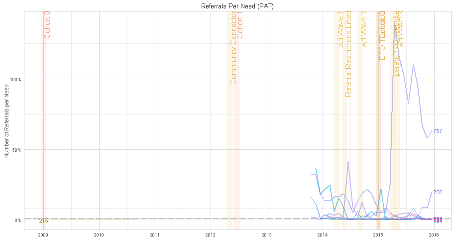

Models will not be run for PAT because there’s not enough information.

## 3.3 SC – Referral

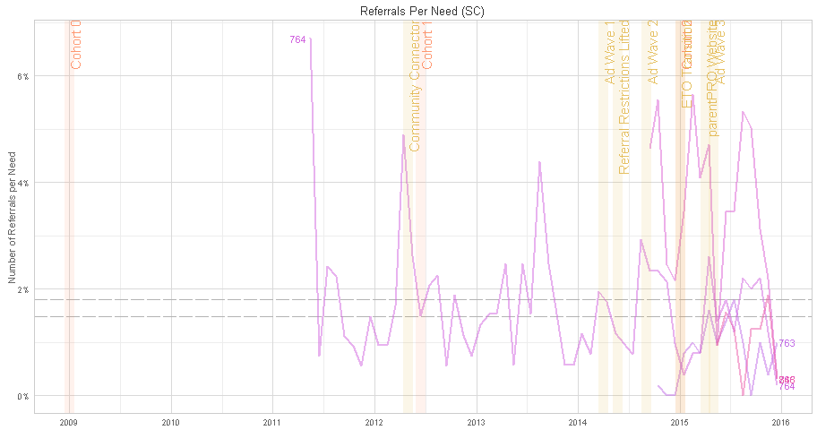

Models will not be run for SC because there’s not enough information.

# 4 Enrollments

## 4.1 HFA – Enroll

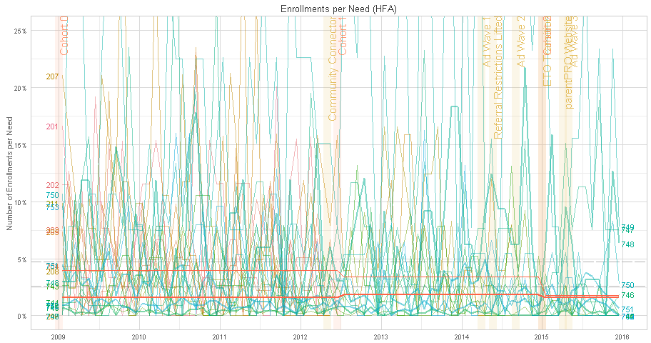

*Response variable*: `EnrollCount`

### 4.1.1 Two-rate coding –MIECHV Contracted

```
               coefficient letter   beta change     p
1               MiechvEver      a -0.918   0.40  .036
2                  Cohort1      b -0.155   0.86  .149
3                  Cohort2      c -0.788   0.45 <.001
4 Cohort1:MiechvContracted      d  0.320   1.38  .003
5 Cohort2:MiechvContracted      e  0.804   2.23  .003
Generalized linear mixed model fit by maximum likelihood (Adaptive Gauss-Hermite Quadrature, nAGQ
  = 0) [glmerMod]
 Family: poisson  ( log )
Formula: EnrollCount ~ 1 + MiechvEver + Cohort1 + Cohort2 + MiechvContracted:Cohort1 +
    MiechvContracted:Cohort2 + Lag1 + Lag2 + Lag3 + (1 + Cohort1 +
    Cohort2 + Lag1 + Lag2 + Lag3 | ProgramCode) + (1 | QuarterF) +
    offset(log(InfantNeedCountPerMonth))
   Data: d

     AIC      BIC   logLik deviance df.resid
  5299.2   5462.3  -2618.6   5237.2     1390

Random effects:
 Groups      Name        Variance Std.Dev. Corr
 QuarterF    (Intercept) 0.018688 0.13670
 ProgramCode (Intercept) 0.751105 0.86666
             Cohort1     0.083505 0.28897   0.30
             Cohort2     0.165029 0.40624   0.07  0.08
             Lag1        0.007601 0.08718  -0.40  0.29 -0.03
             Lag2        0.003557 0.05964  -0.23 -0.64 -0.57 -0.48
             Lag3        0.007712 0.08782   0.13 -0.68  0.25 -0.15  0.35
Number of obs: 1421, groups:  QuarterF, 27; ProgramCode, 23

Fixed effects:
                          Estimate Std. Error z value Pr(>|z|)
(Intercept)              -3.207145   0.204219 -15.704  < 2e-16
MiechvEver               -0.918229   0.436974  -2.101  0.03561
Cohort1                  -0.154817   0.107206  -1.444  0.14871
Cohort2                  -0.788033   0.190957  -4.127 3.68e-05
Lag1                      0.021081   0.037493   0.562  0.57393
Lag2                      0.007043   0.034129   0.206  0.83651
Lag3                     -0.052671   0.037614  -1.400  0.16142
Cohort1:MiechvContracted  0.319631   0.107184   2.982  0.00286
Cohort2:MiechvContracted  0.804208   0.271609   2.961  0.00307
```

### 4.1.2 Two-rate coding –Has Community Connector

```
           coefficient letter   beta change     p
1           MiechvEver      a -1.158   0.31  .009
2              Cohort1      b -0.053   0.95  .634
3              Cohort2      c -0.658   0.52  .001
4 Cohort1:HasConnector      d -0.106   0.90  .446
5 Cohort2:HasConnector      e  0.504   1.66  .043
      AIC       BIC    logLik  deviance  df.resid
 5310.809  5473.841 -2624.404  5248.809  1390.000
```

### 4.1.3 Event: Ad Waves

*Event Description*: parentPRO ad campaigns in 2014 and 2015 - Apr 01, 2014

```
               coefficient letter   beta change     p
1                AdWaveAny      h  0.215   1.24  .063
2               MiechvEver      i -0.913   0.40  .038
3                  Cohort1      j -0.186   0.83  .097
4                  Cohort2      k -0.791   0.45 <.001
5 Cohort1:MiechvContracted      l  0.297   1.35  .007
6 Cohort2:MiechvContracted      m  0.810   2.25  .003
      AIC       BIC    logLik  deviance  df.resid
 5298.160  5466.452 -2617.080  5234.160  1389.000
```

### 4.1.4 Event: Ad Wave 1

*Event Description*: parentPRO ad campaign concentrated in May. - Apr 01, 2014

```
               coefficient letter   beta change     p
1                  AdWave1      h -0.156   0.86  .382
2               MiechvEver      i -0.918   0.40  .036
3                  Cohort1      j -0.142   0.87  .189
4                  Cohort2      k -0.789   0.45 <.001
5 Cohort1:MiechvContracted      l  0.329   1.39  .002
6 Cohort2:MiechvContracted      m  0.807   2.24  .003
      AIC       BIC    logLik  deviance  df.resid
 5300.479  5468.771 -2618.240  5236.479  1389.000
```

### 4.1.5 Event: Ad Wave 2

*Event Description*: parentPRO ad campaign concentrated in late Sept. - Sep 01, 2014

```
               coefficient letter   beta change     p
1                  AdWave2      h  0.374   1.45  .005
2               MiechvEver      i -0.909   0.40  .039
3                  Cohort1      j -0.177   0.84  .106
4                  Cohort2      k -0.794   0.45 <.001
5 Cohort1:MiechvContracted      l  0.297   1.35  .006
6 Cohort2:MiechvContracted      m  0.820   2.27  .003
      AIC       BIC    logLik  deviance  df.resid
 5293.846  5462.137 -2614.923  5229.846  1389.000
```

### 4.1.6 Event: Referral Restrictions Lifted

*Event Description*: Substantial restrictions lifted for inter-agency collaboration. - May 23, 2014

```
               coefficient letter   beta change     p
1                EraLifted      h -0.133   0.88  .340
2               MiechvEver      i -0.918   0.40  .036
3                  Cohort1      j -0.153   0.86  .149
4                  Cohort2      k -0.787   0.46 <.001
5 Cohort1:MiechvContracted      l  0.369   1.45  .002
6 Cohort2:MiechvContracted      m  0.937   2.55  .002
      AIC       BIC    logLik  deviance  df.resid
 5300.332  5468.623 -2618.166  5236.332  1389.000
```

### 4.1.7 Event: ETO Transition

*Event Description*: Staff transitions from OCAPPA data system to ETO (deployed Jan 1). - Jan 01, 2015

```
               coefficient letter   beta change     p
1            EtoTransition      h  0.088   1.09  .581
2               MiechvEver      i -0.919   0.40  .036
3                  Cohort1      j -0.155   0.86  .147
4                  Cohort2      k -0.818   0.44 <.001
5 Cohort1:MiechvContracted      l  0.319   1.38  .003
6 Cohort2:MiechvContracted      m  0.804   2.23  .003
      AIC       BIC    logLik  deviance  df.resid
 5300.937  5469.229 -2618.468  5236.937  1389.000
```

### 4.1.8 Event: parentPRO Website

*Event Description*: The state’s umbrella website is deployed. - Apr 02, 2015

```
               coefficient letter   beta change     p
1               EraWebsite      h -0.161   0.85  .426
2               MiechvEver      i -0.923   0.40  .035
3                  Cohort1      j -0.155   0.86  .148
4                  Cohort2      k -0.668   0.51  .006
5 Cohort1:MiechvContracted      l  0.320   1.38  .003
6 Cohort2:MiechvContracted      m  0.804   2.23  .003
      AIC       BIC    logLik  deviance  df.resid
 5300.612  5468.904 -2618.306  5236.612  1389.000
```

### 4.1.9 Event: Ad Wave 3

*Event Description*: parentPRO ad campaign concentrated in late May. - May 01, 2015

```
               coefficient letter   beta change     p
1                  AdWave3      h  0.126   1.13  .502
2               MiechvEver      i -0.918   0.40  .035
3                  Cohort1      j -0.155   0.86  .148
4                  Cohort2      k -0.810   0.44 <.001
5 Cohort1:MiechvContracted      l  0.318   1.37  .003
6 Cohort2:MiechvContracted      m  0.807   2.24  .003
      AIC       BIC    logLik  deviance  df.resid
 5300.795  5469.087 -2618.397  5236.795  1389.000
```

## 4.2 PAT – Enroll

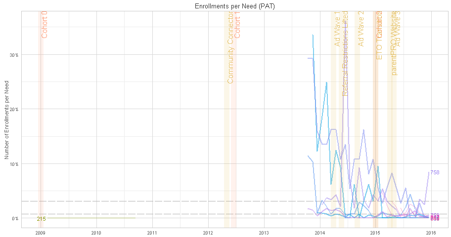

Models will not be run for PAT because there’s not enough information.

## 4.3 SC – Enroll

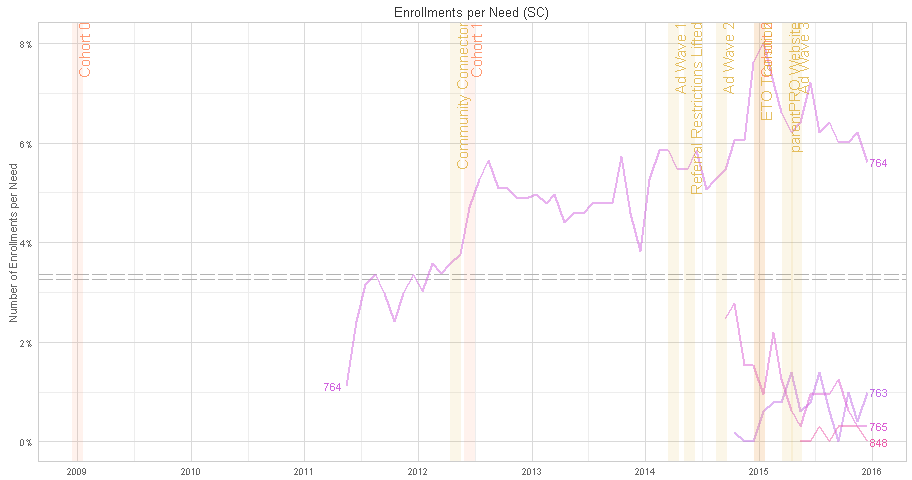

Models will not be run for SC because there’s not enough information.

# 5 Completed Visits Per Need

## 5.1 HFA – Visit

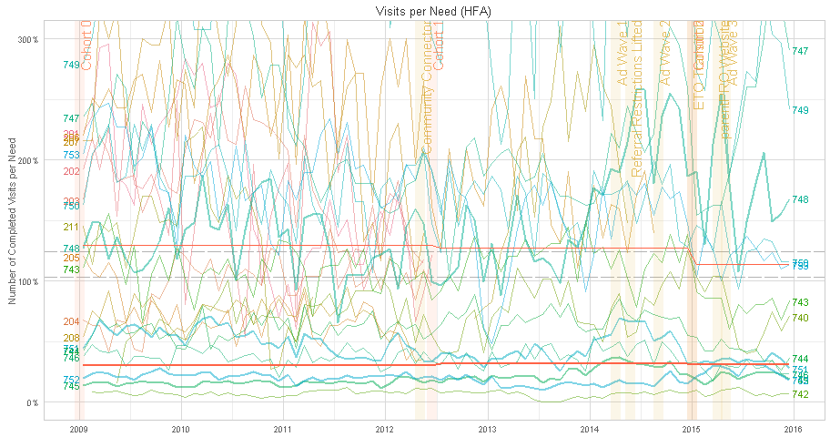

*Response variable*: `VisitCompletedCount`

### 5.1.1 Two-rate coding –MIECHV Contracted

```
               coefficient letter   beta change     p
1               MiechvEver      a -1.460   0.23  .001
2                  Cohort1      b -0.017   0.98  .585
3                  Cohort2      c -0.132   0.88  .002
4 Cohort1:MiechvContracted      d  0.078   1.08  .001
5 Cohort2:MiechvContracted      e  0.175   1.19  .002
Generalized linear mixed model fit by maximum likelihood (Adaptive Gauss-Hermite Quadrature, nAGQ
  = 0) [glmerMod]
 Family: poisson  ( log )
Formula: VisitCompletedCount ~ 1 + MiechvEver + Cohort1 + Cohort2 + MiechvContracted:Cohort1 +
    MiechvContracted:Cohort2 + Lag1 + Lag2 + Lag3 + (1 + Cohort1 +
    Cohort2 + Lag1 + Lag2 + Lag3 | ProgramCode) + (1 | QuarterF) +
    offset(log(InfantNeedCountPerMonth))
   Data: d

     AIC      BIC   logLik deviance df.resid
 11564.7  11727.7  -5751.3  11502.7     1390

Random effects:
 Groups      Name        Variance Std.Dev. Corr
 QuarterF    (Intercept) 0.001508 0.03884
 ProgramCode (Intercept) 1.166295 1.07995
             Cohort1     0.008687 0.09320   0.02
             Cohort2     0.012045 0.10975  -0.56  0.15
             Lag1        0.044279 0.21042  -0.57  0.07  0.67
             Lag2        0.003123 0.05589   0.04 -0.20 -0.63 -0.72
             Lag3        0.002640 0.05138   0.35 -0.45 -0.09 -0.39  0.42
Number of obs: 1421, groups:  QuarterF, 27; ProgramCode, 23

Fixed effects:
                         Estimate Std. Error z value Pr(>|z|)
(Intercept)              -1.98661    0.25279  -7.859 3.88e-15
MiechvEver               -1.46011    0.45847  -3.185  0.00145
Cohort1                  -0.01712    0.03132  -0.547  0.58471
Cohort2                  -0.13173    0.04189  -3.145  0.00166
Lag1                      0.43078    0.04823   8.931  < 2e-16
Lag2                      0.05293    0.02320   2.282  0.02252
Lag3                      0.05823    0.02080   2.800  0.00511
Cohort1:MiechvContracted  0.07780    0.02415   3.222  0.00127
Cohort2:MiechvContracted  0.17519    0.05531   3.168  0.00154
```

### 5.1.2 Two-rate coding –Has Community Connector

```
           coefficient letter   beta change     p
1           MiechvEver      a -1.427   0.24  .002
2              Cohort1      b  0.012   1.01  .736
3              Cohort2      c -0.121   0.89  .004
4 Cohort1:HasConnector      d -0.034   0.97  .359
5 Cohort2:HasConnector      e  0.142   1.15  .003
      AIC       BIC    logLik  deviance  df.resid
11574.270 11737.302 -5756.135 11512.270  1390.000
```

### 5.1.3 Event: Ad Waves

*Event Description*: parentPRO ad campaigns in 2014 and 2015 - Apr 01, 2014

```
               coefficient letter   beta change     p
1                AdWaveAny      h  0.151   1.16 <.001
2               MiechvEver      i -1.422   0.24  .002
3                  Cohort1      j -0.043   0.96  .177
4                  Cohort2      k -0.130   0.88  .002
5 Cohort1:MiechvContracted      l  0.067   1.07  .005
6 Cohort2:MiechvContracted      m  0.173   1.19  .002
      AIC       BIC    logLik  deviance  df.resid
11525.641 11693.933 -5730.821 11461.641  1389.000
```

### 5.1.4 Event: Ad Wave 1

*Event Description*: parentPRO ad campaign concentrated in May. - Apr 01, 2014

```
               coefficient letter   beta change     p
1                  AdWave1      h  0.054   1.06  .223
2               MiechvEver      i -1.460   0.23  .001
3                  Cohort1      j -0.022   0.98  .476
4                  Cohort2      k -0.132   0.88  .002
5 Cohort1:MiechvContracted      l  0.076   1.08  .002
6 Cohort2:MiechvContracted      m  0.175   1.19  .002
      AIC       BIC    logLik  deviance  df.resid
11565.247 11733.539 -5750.624 11501.247  1389.000
```

### 5.1.5 Event: Ad Wave 2

*Event Description*: parentPRO ad campaign concentrated in late Sept. - Sep 01, 2014

```
               coefficient letter   beta change     p
1                  AdWave2      h  0.174   1.19 <.001
2               MiechvEver      i -1.413   0.24  .002
3                  Cohort1      j -0.032   0.97  .313
4                  Cohort2      k -0.129   0.88  .002
5 Cohort1:MiechvContracted      l  0.071   1.07  .003
6 Cohort2:MiechvContracted      m  0.172   1.19  .002
      AIC       BIC    logLik  deviance  df.resid
11524.384 11692.676 -5730.192 11460.384  1389.000
```

### 5.1.6 Event: Referral Restrictions Lifted

*Event Description*: Substantial restrictions lifted for inter-agency collaboration. - May 23, 2014

```
               coefficient letter   beta change     p
1                EraLifted      h -0.026   0.97  .365
2               MiechvEver      i -1.465   0.23  .001
3                  Cohort1      j -0.017   0.98  .582
4                  Cohort2      k -0.133   0.88  .001
5 Cohort1:MiechvContracted      l  0.085   1.09  .001
6 Cohort2:MiechvContracted      m  0.202   1.22  .001
      AIC       BIC    logLik  deviance  df.resid
11566.639 11734.931 -5751.319 11502.639  1389.000
```

### 5.1.7 Event: ETO Transition

*Event Description*: Staff transitions from OCAPPA data system to ETO (deployed Jan 1). - Jan 01, 2015

```
               coefficient letter   beta change     p
1            EtoTransition      h  0.136   1.15 <.001
2               MiechvEver      i -1.433   0.24  .002
3                  Cohort1      j -0.016   0.98  .622
4                  Cohort2      k -0.174   0.84 <.001
5 Cohort1:MiechvContracted      l  0.077   1.08  .002
6 Cohort2:MiechvContracted      m  0.173   1.19  .002
      AIC       BIC    logLik  deviance  df.resid
11553.195 11721.486 -5744.597 11489.195  1389.000
```

### 5.1.8 Event: parentPRO Website

*Event Description*: The state’s umbrella website is deployed. - Apr 02, 2015

```
               coefficient letter   beta change     p
1               EraWebsite      h  0.019   1.02  .710
2               MiechvEver      i -1.461   0.23  .001
3                  Cohort1      j -0.017   0.98  .589
4                  Cohort2      k -0.146   0.86  .010
5 Cohort1:MiechvContracted      l  0.078   1.08  .001
6 Cohort2:MiechvContracted      m  0.175   1.19  .002
     AIC      BIC   logLik deviance df.resid
11566.56 11734.85 -5751.28 11502.56  1389.00
```

### 5.1.9 Event: Ad Wave 3

*Event Description*: parentPRO ad campaign concentrated in late May. - May 01, 2015

```
               coefficient letter   beta change     p
1                  AdWave3      h -0.167   0.85 <.001
2               MiechvEver      i -1.420   0.24  .002
3                  Cohort1      j -0.017   0.98  .594
4                  Cohort2      k -0.100   0.90  .022
5 Cohort1:MiechvContracted      l  0.076   1.08  .002
6 Cohort2:MiechvContracted      m  0.172   1.19  .002
      AIC       BIC    logLik  deviance  df.resid
11549.717 11718.009 -5742.859 11485.717  1389.000
```

## 5.2 PAT – Visit

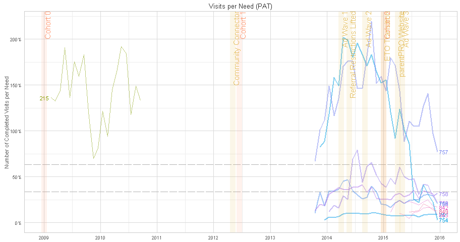

Models will not be run for PAT because there’s not enough information.

## 5.3 SC – Visit

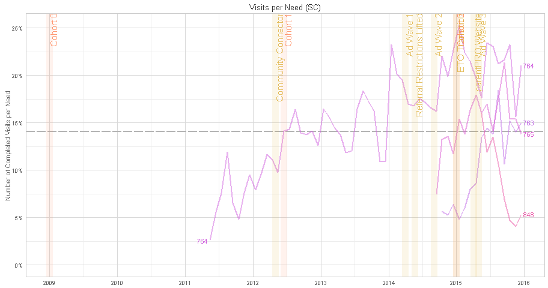

Models will not be run for SC because there’s not enough information.